# act_report

## Report: act_report

Within the "WeRateDogs" project I gathered various datasets based on the Twitter user "dog_rates" and his tweets about dog ratings.

With the given data I was able to get an overview of the most often posted dogs, the favorite dogs amongst the account followers, and the overall ratings given. Let's start at the beginning. All the tweets combined show an immensive amount of dog breeds rated by "dog_rates", but there seems to be favorites amongst the user. A well-owned first place goes to the Golden Retriever showing op the most in all the tweets created (see Figure 1). Also popular on the second and third place we find the Pembroke (a Corgi breed) and the Labrador Retriever.

###### Figure 1

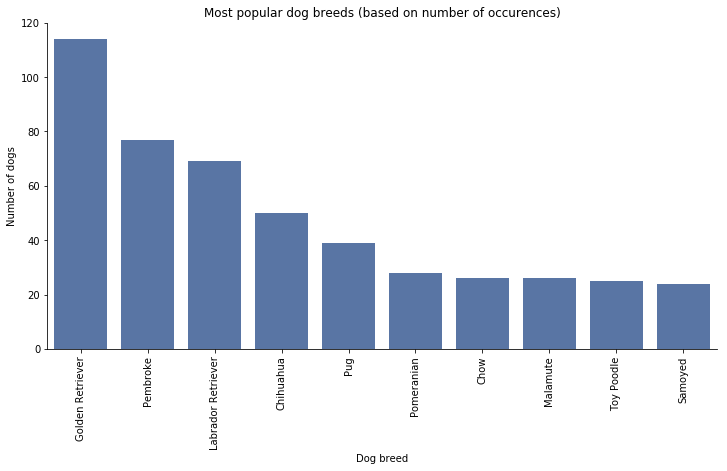

#### Table 1

| Dog breed | sum of favorite count |
| --- | --- |
| Golden Retriever | 1225225 |
| Pembroke | 840447 |
| Labarador Retriever | 562763 |
| Chihuahua | 419372 |
| French Bulldog | 333379 |

[figure not shown]

The last finding involves the overall way of rating dogs by the account. The maximum of the scale of ratings (the "denominator") is set to 10. As we are talking about dogs and they are supposed to be sweet and fabulous all the time, the account owner gives a mean rating of 10.95 per dog and therefore exceeding the set denominator of 10 regularly. So while dogs get an fabulous rating on average, there are still outliers present with a top rating of 26 and 27 ("extraordinary dog") or even low rating of 2 ("bad dog"). Overall we can say that the account owner is a good person not trying to upset the dog owners except something is really off, but that seems to be rarely the case. In the end it's an account for enlightening your day with nice dog :)